# Lab 4: Otros modelos de clasificación - Otoño 2021

Nicolás Acevedo, Constanza Bastías y Pablo Ubilla

23/6/2021

# Machine Learning

Machine Learning es un conjunto de métodos que Automatizar la construcción de modelos analíticos y se basa en la idea de que los sistemas pueden aprender de los datos, identificar patrones y tomar decisiones con una mínima intervención humana.

Los problemas más típicos que resuelven los modelos de Machine Learning son 2:

1. Regresiones: Predicción de una variable continua
2. Clasificación: Predeción de una variable discreta

# Laboratorio

## El Dataset

Trabajaremos con una base de datos que contiene los resultados de un análisis químico de vinos cultivados en Italia. Tres diferentes tipos de vino están representados en las 178 muestras, con los resultados de 13 análisis químicos registrados para cada muestra. La variable ‘Type’ corresponde a la variable categórica.

Los datos no contienen valores perdidos y se componen de solo datos numéricos, con la variable objetivo de tres clases ‘Type’ para la clasificación.

A continuación un diccionario de las variables:

- **Type** : Tipo de vino (factor)
- **Alcohol** : Alcohol (numérica)
- **Malic**: Ácido málico (numérica)
- **Ash**: Ceniza (numérica)
- **Alcalinity**: Alcalinidad de la ceniza (numérica)
- **Magnesium**: Magnesio (numérica)
- **Phenols**: Fenoles totales (numérica)
- **Flavanoids**: Flavonoides (numérica)
- **Nonflavanoids**: Fenoles no flavonoides (numérica)
- **Proanthocyanins** : Proantocianinas (numérica)
- **Color**: Intensidad del color (numérica)
- **Hue**: Matiz (numérica)
- **Dilution**: D280 / OD315 de vinos diluidos (numérica)
- **Proline**: Prolina (numérica)

Head del dataset:

```r
head(wine[sample(nrow(wine),6 ), ])
```

|  | Type | Alcohol | Malic | Ash | Alcalinity | Magnesium | Phenols | Flavanoids | Nonflavanoids | Proanthocyanins | Color | Hue | Dilution | Proline |
| --- | --- | --- | --- | --- | --- | --- | --- | --- | --- | --- | --- | --- | --- | --- |
| 142 | 3 | 13.36 | 2.56 | 2.35 | 20.0 | 89 | 1.40 | 0.50 | 0.37 | 0.64 | 5.60 | 0.70 | 2.47 | 780 |
| 51 | 1 | 13.05 | 1.73 | 2.04 | 12.4 | 92 | 2.72 | 3.27 | 0.17 | 2.91 | 7.20 | 1.12 | 2.91 | 1150 |
| 152 | 3 | 12.79 | 2.67 | 2.48 | 22.0 | 112 | 1.48 | 1.36 | 0.24 | 1.26 | 10.80 | 0.48 | 1.47 | 480 |
| 58 | 1 | 13.29 | 1.97 | 2.68 | 16.8 | 102 | 3.00 | 3.23 | 0.31 | 1.66 | 6.00 | 1.07 | 2.84 | 1270 |
| 93 | 2 | 12.69 | 1.53 | 2.26 | 20.7 | 80 | 1.38 | 1.46 | 0.58 | 1.62 | 3.05 | 0.96 | 2.06 | 495 |
| 75 | 2 | 11.96 | 1.09 | 2.30 | 21.0 | 101 | 3.38 | 2.14 | 0.13 | 1.65 | 3.21 | 0.99 | 3.13 | 886 |

## EDA

Vemos la distribución de los tipos de vino en el dataset:

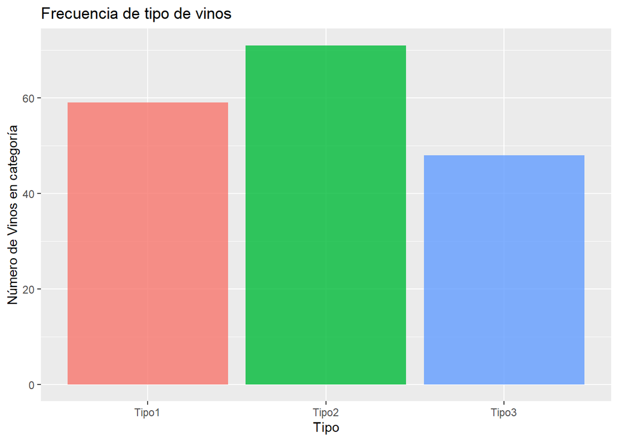

```r
ggplot(wine, aes(Type, fill=Type)) + geom_bar(alpha=0.8) +
  labs(x="Tipo", y="Número de Vinos en categoría") +
  guides(fill=FALSE)+ggtitle("Frecuencia de tipo de vinos")
```

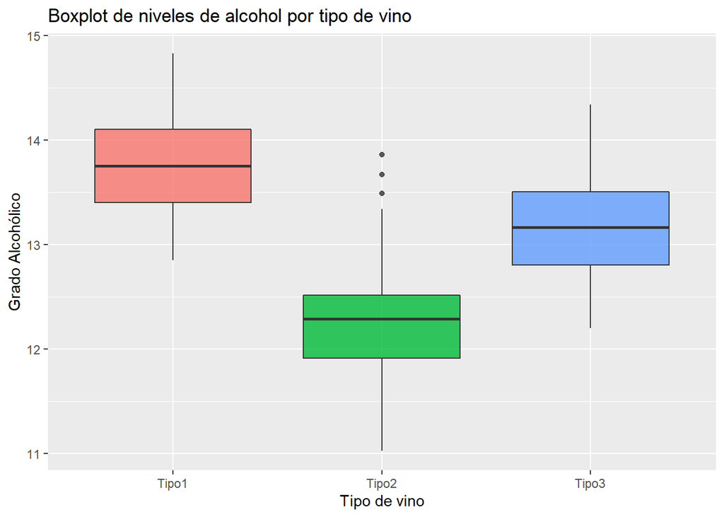

```r
ggplot(wine, aes(x=Type,y=Alcohol,fill=Type)) +
  geom_boxplot(alpha=0.8) +
  labs(fill="Tipo", x="Tipo de vino", y="Grado Alcohólico")+ggtitle("Boxplot de niveles de alcohol por tipo de vino")+guides(fill=FALSE)
```

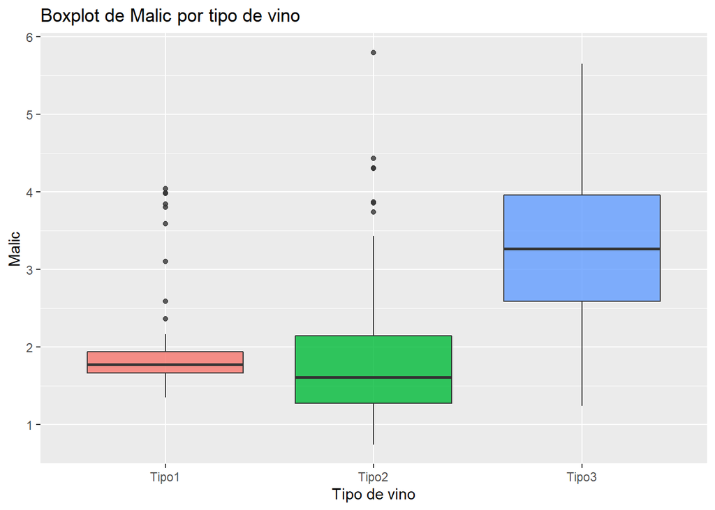

```r
ggplot(wine, aes(x=Type,y=Malic,fill=Type)) +
  geom_boxplot(alpha=0.8) +
  labs(fill="Tipo", x="Tipo de vino", y="Malic")+ggtitle("Boxplot de Malic por tipo de vino")+guides(fill=FALSE)
```

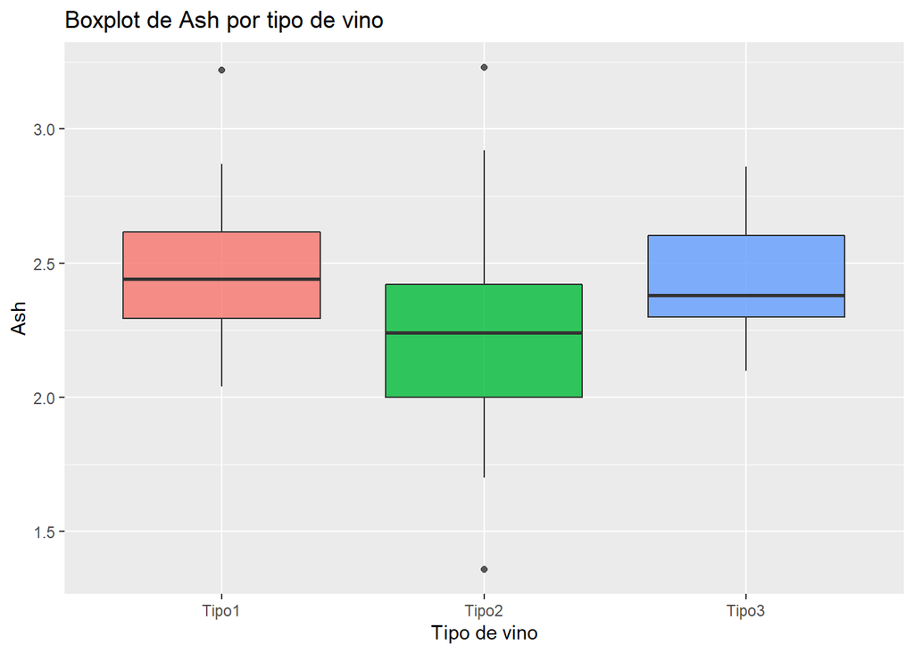

```r
ggplot(wine, aes(x=Type,y=Ash,fill=Type)) +
  geom_boxplot(alpha=0.8) +
  labs(fill="Tipo", x="Tipo de vino", y="Ash")+ggtitle("Boxplot de Ash por tipo de vino")+guides(fill=FALSE)
```

[figure not shown]

```r
ggplot(wine, aes(Alcalinity, fill=Type)) +
  geom_histogram(binwidth=1,alpha=0.8) +
  labs(fill="Tipo", x="Grados de alcohol", y="Número de vinos")+ggtitle("Frecuencia de Alcalinidad por tipo de vino")
```

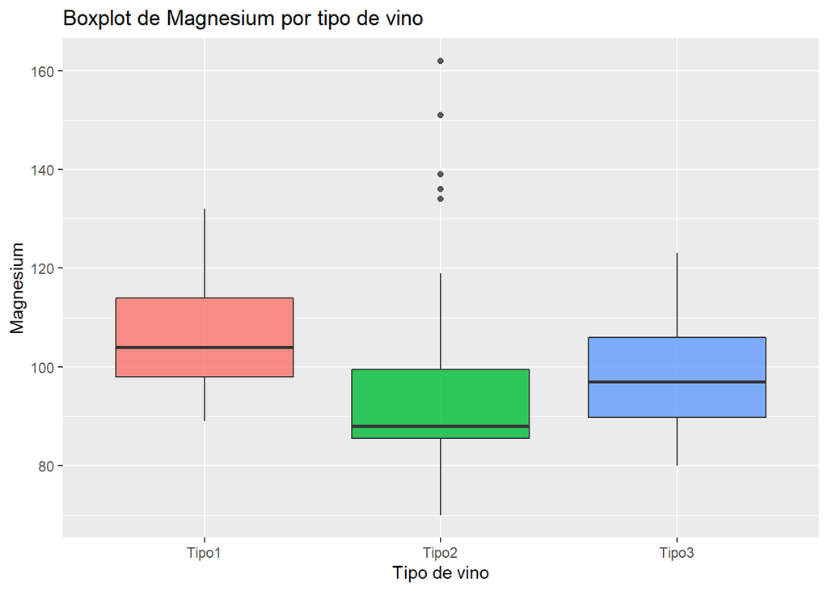

```r
ggplot(wine, aes(x=Type,y=Magnesium,fill=Type)) +
  geom_boxplot(alpha=0.8) +
  labs(fill="Tipo", x="Tipo de vino", y="Magnesium")+ggtitle("Boxplot de Magnesium por tipo de vino")+guides(fill=FALSE)
```

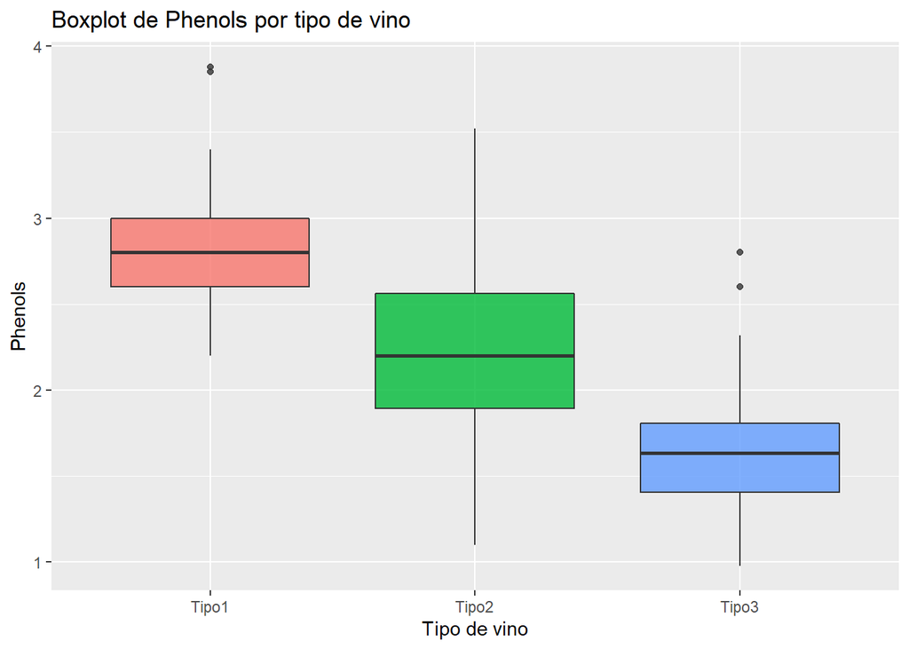

```r
ggplot(wine, aes(x=Type,y=Phenols,fill=Type)) +
  geom_boxplot(alpha=0.8) +
  labs(fill="Tipo", x="Tipo de vino", y="Phenols")+ggtitle("Boxplot de Phenols por tipo de vino")+guides(fill=FALSE)
```

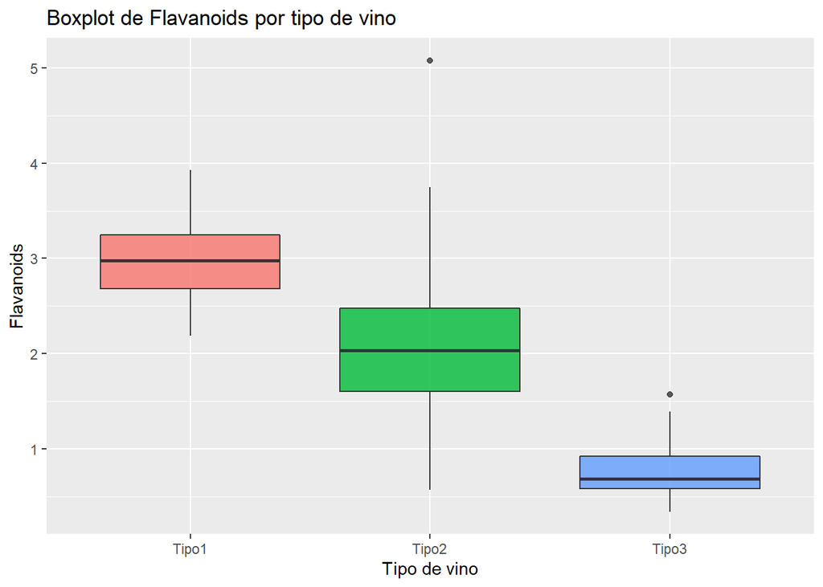

```r
ggplot(wine, aes(x=Type,y=Flavanoids,fill=Type)) +
  geom_boxplot(alpha=0.8) +
  labs(fill="Tipo", x="Tipo de vino", y="Flavanoids")+ggtitle("Boxplot de Flavanoids por tipo de vino")+guides(fill=FALSE)
```

[figure not shown]

```r
ggplot(wine, aes(x=Type,y=Nonflavanoids,fill=Type)) +
  geom_boxplot(alpha=0.8) +
  labs(fill="Tipo", x="Tipo de vino", y="Flavanoids")+ggtitle("Boxplot de Flavanoids por tipo de vino")+guides(fill=FALSE)
```

[figure not shown]

```r
ggplot(wine, aes(x=Type,y=Proanthocyanins,fill=Type)) +
  geom_boxplot(alpha=0.8) +
  labs(fill="Tipo", x="Tipo de vino", y="Flavanoids")+ggtitle("Boxplot de Flavanoids por tipo de vino")+guides(fill=FALSE)
```

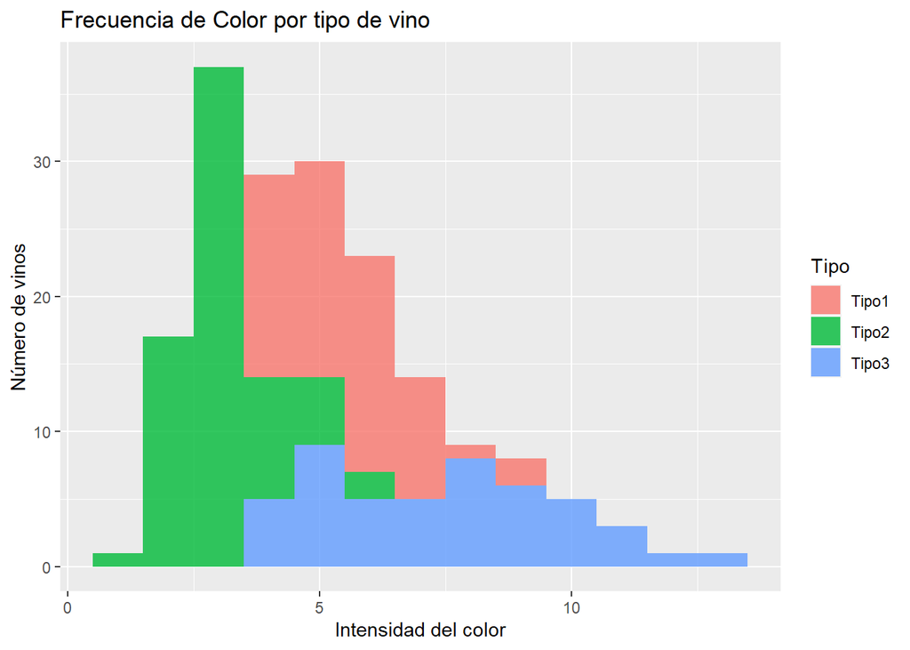

```r
ggplot(wine, aes(Color, fill=Type)) +
  geom_histogram(binwidth=1,alpha=0.8) +
  labs(fill="Tipo", x="Intensidad del color", y="Número de vinos")+ggtitle("Frecuencia de Color por tipo de vino")
```

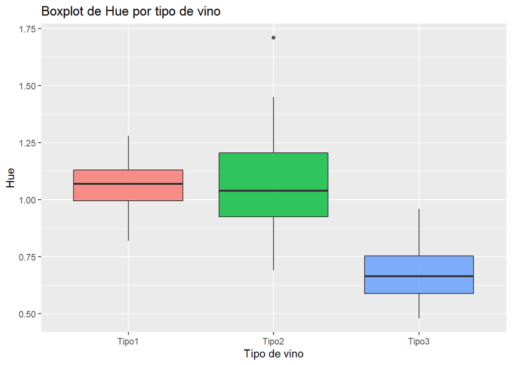

```r
ggplot(wine, aes(x=Type,y=Hue,fill=Type)) +
  geom_boxplot(alpha=0.8) +
  labs(fill="Tipo", x="Tipo de vino", y="Hue")+ggtitle("Boxplot de Hue por tipo de vino")+guides(fill=FALSE)
```

[figure not shown]

```r
ggplot(wine, aes(x=Type,y=Dilution,fill=Type)) +
  geom_boxplot(alpha=0.8) +
  labs(fill="Tipo", x="Tipo de vino", y="Dilution")+ggtitle("Boxplot de Hue por tipo de vino")+guides(fill=FALSE)
```

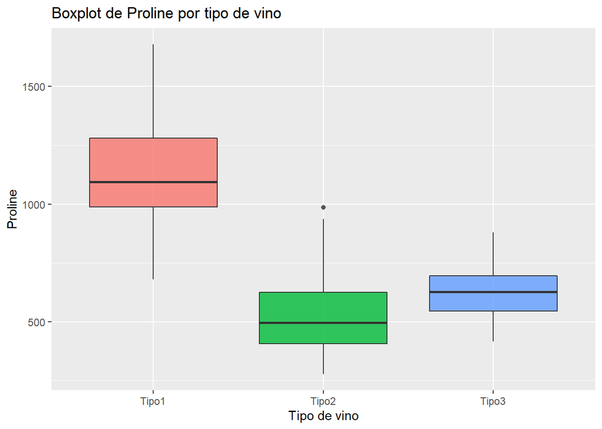

```r
ggplot(wine, aes(x=Type,y=Proline,fill=Type)) +
  geom_boxplot(alpha=0.8) +
  labs(fill="Tipo", x="Tipo de vino", y="Proline")+ggtitle("Boxplot de Proline por tipo de vino")+guides(fill=FALSE)
```

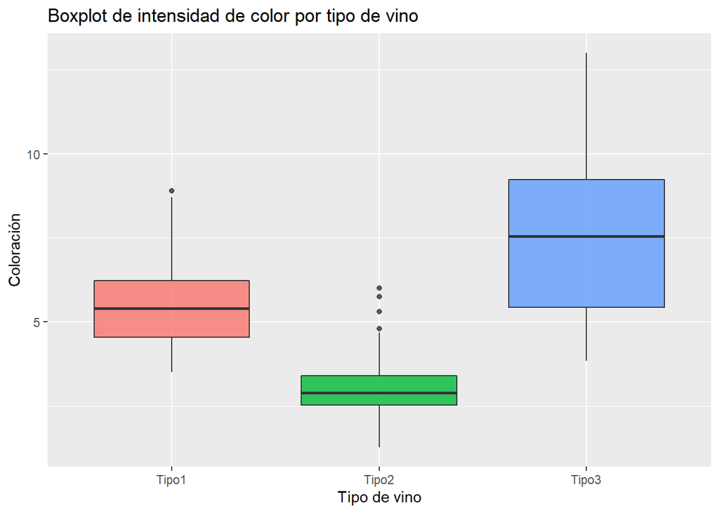

```r
ggplot(wine, aes(x=Type,y=Color,fill=Type)) +
  geom_boxplot(alpha=0.8) +
  labs(fill="Tipo", x="Tipo de vino", y="Coloración")+ggtitle("Boxplot de intensidad de color por tipo de vino")+guides(fill=FALSE)
```

## KNN

### K-Nearest Neighbors

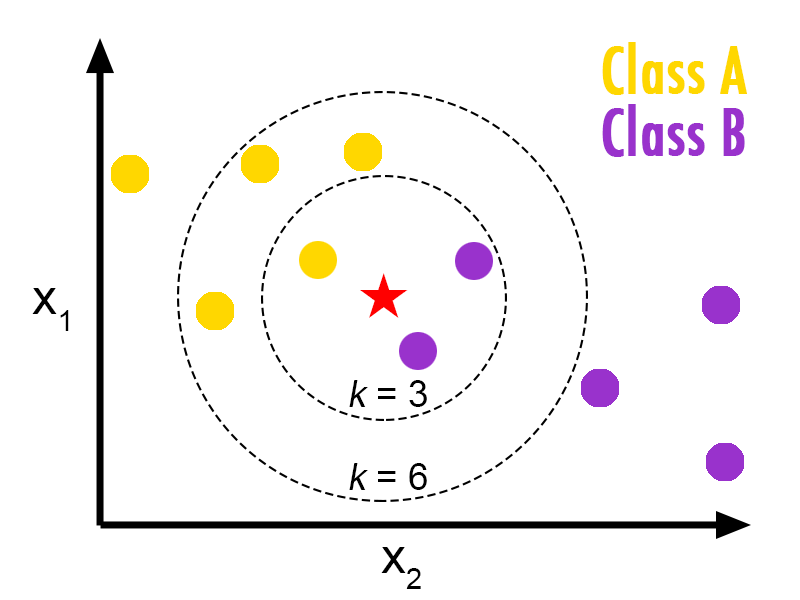

```r
trainwine=wine[sample(nrow(wine),100 ), ]
testwine=anti_join(wine, trainwine)
train.knn <- train( Type ~.,data=trainwine, method="knn",
                   trControl  = trainControl("cv",number=5,classProbs=TRUE, summaryFunction=multiClassSummary),
                   preProcess = c("center","scale"),
                   tuneLength = 6,
                   metric = 'logLoss')

print(train.knn)
```

```
## k-Nearest Neighbors
##
## 100 samples
##  13 predictor
##   3 classes: 'Tipo1', 'Tipo2', 'Tipo3'
##
## Pre-processing: centered (13), scaled (13)
## Resampling: Cross-Validated (5 fold)
## Summary of sample sizes: 80, 80, 80, 80, 80
## Resampling results across tuning parameters:
##
##   k   logLoss     AUC        prAUC      Accuracy  Kappa      Mean_F1
##    5  0.41193061  0.9916636  0.1128872  0.95      0.9219531  0.9521666
##    7  0.08907448  0.9968614  0.1539819  0.97      0.9524235  0.9753148
##    9  0.09552422  0.9965213  0.1968579  0.98      0.9680485  0.9836808
##   11  0.10410556  0.9985940  0.2933923  0.97      0.9524235  0.9753148
##   13  0.11278325  0.9958479  0.3235511  0.98      0.9680485  0.9836808
##   15  0.13163174  0.9948116  0.4075729  0.98      0.9680485  0.9836808
##   Mean_Sensitivity  Mean_Specificity  Mean_Pos_Pred_Value  Mean_Neg_Pred_Value
##   0.9637037         0.9762821         0.9483333            0.9725719
##   0.9785185         0.9846154         0.9750000            0.9828283
##   0.9859259         0.9897436         0.9833333            0.9883838
##   0.9785185         0.9846154         0.9750000            0.9828283
##   0.9859259         0.9897436         0.9833333            0.9883838
##   0.9859259         0.9897436         0.9833333            0.9883838
##   Mean_Precision  Mean_Recall  Mean_Detection_Rate  Mean_Balanced_Accuracy
##   0.9483333       0.9637037    0.3166667            0.9699929
##   0.9750000       0.9785185    0.3233333            0.9815670
##   0.9833333       0.9859259    0.3266667            0.9878348
##   0.9750000       0.9785185    0.3233333            0.9815670
##   0.9833333       0.9859259    0.3266667            0.9878348
##   0.9833333       0.9859259    0.3266667            0.9878348
##
## logLoss was used to select the optimal model using the smallest value.
## The final value used for the model was k = 7.
```

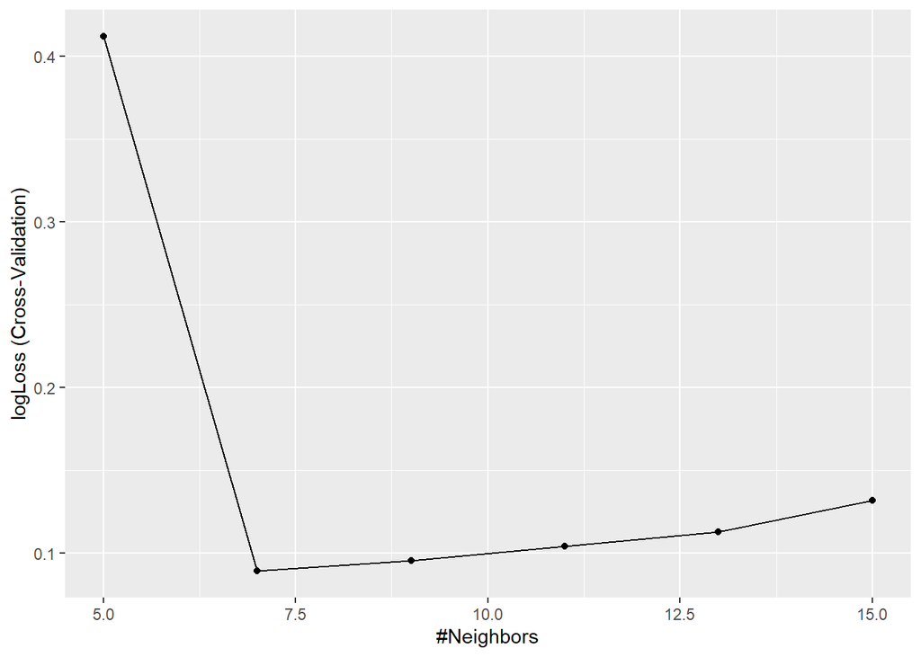

```r
ggplot(train.knn)
```

```r
train.knn$results
```

|  | k | logLoss | AUC | prAUC | Accuracy | Kappa | Mean_F1 | Mean_Sensitivity | Mean_Specificity | Mean_Pos_Pred_Value | Mean_Neg_Pred_Value | Mean_Precision | Mean_Recall | Mean_Detection_Rate | Mean_Balanced_Accuracy | logLossSD | AUCSD | prAUCSD | AccuracySD | KappaSD | Mean_F1SD | Mean_SensitivitySD | Mean_SpecificitySD | Mean_Pos_Pred_ValueSD | Mean_Neg_Pred_ValueSD | Mean_PrecisionSD | Mean_RecallSD | Mean_Detection_RateSD | Mean_Balanced_AccuracySD |
| --- | --- | --- | --- | --- | --- | --- | --- | --- | --- | --- | --- | --- | --- | --- | --- | --- | --- | --- | --- | --- | --- | --- | --- | --- | --- | --- | --- | --- | --- |
| 1 | 5 | 0.41193061 | 0.9916636 | 0.1128872 | 0.95 | 0.9219531 | 0.9521666 | 0.9637037 | 0.9762821 | 0.9483333 | 0.9725719 | 0.9483333 | 0.9637037 | 0.3166667 | 0.9699929 | 0.76951114 | 0.015894915 | 0.07450709 | 0.03535534 | 0.05422495 | 0.03635112 | 0.02624147 | 0.01655380 | 0.03970376 | 0.01823336 | 0.03970376 | 0.02624147 | 0.011785113 | 0.02132907 |
| 2 | 7 | 0.08907448 | 0.9968614 | 0.1539819 | 0.97 | 0.9524235 | 0.9753148 | 0.9785185 | 0.9846154 | 0.9750000 | 0.9828283 | 0.9750000 | 0.9785185 | 0.3233333 | 0.9815670 | 0.05876463 | 0.004687883 | 0.03748730 | 0.02738613 | 0.04345483 | 0.02255019 | 0.01966803 | 0.01404417 | 0.02282177 | 0.01570943 | 0.02282177 | 0.01966803 | 0.009128709 | 0.01684397 |
| 3 | 9 | 0.09552422 | 0.9965213 | 0.1968579 | 0.98 | 0.9680485 | 0.9836808 | 0.9859259 | 0.9897436 | 0.9833333 | 0.9883838 | 0.9833333 | 0.9859259 | 0.3266667 | 0.9878348 | 0.05920662 | 0.004912760 | 0.07542080 | 0.02738613 | 0.04376901 | 0.02235794 | 0.01931616 | 0.01404417 | 0.02282177 | 0.01593112 | 0.02282177 | 0.01931616 | 0.009128709 | 0.01667081 |
| 4 | 11 | 0.10410556 | 0.9985940 | 0.2933923 | 0.97 | 0.9524235 | 0.9753148 | 0.9785185 | 0.9846154 | 0.9750000 | 0.9828283 | 0.9750000 | 0.9785185 | 0.3233333 | 0.9815670 | 0.04993827 | 0.003143915 | 0.10781747 | 0.02738613 | 0.04345483 | 0.02255019 | 0.01966803 | 0.01404417 | 0.02282177 | 0.01570943 | 0.02282177 | 0.01966803 | 0.009128709 | 0.01684397 |
| 5 | 13 | 0.11278325 | 0.9958479 | 0.3235511 | 0.98 | 0.9680485 | 0.9836808 | 0.9859259 | 0.9897436 | 0.9833333 | 0.9883838 | 0.9833333 | 0.9859259 | 0.3266667 | 0.9878348 | 0.06038256 | 0.006168435 | 0.10400520 | 0.02738613 | 0.04376901 | 0.02235794 | 0.01931616 | 0.01404417 | 0.02282177 | 0.01593112 | 0.02282177 | 0.01931616 | 0.009128709 | 0.01667081 |
| 6 | 15 | 0.13163174 | 0.9948116 | 0.4075729 | 0.98 | 0.9680485 | 0.9836808 | 0.9859259 | 0.9897436 | 0.9833333 | 0.9883838 | 0.9833333 | 0.9859259 | 0.3266667 | 0.9878348 | 0.05181722 | 0.007317149 | 0.09746725 | 0.02738613 | 0.04376901 | 0.02235794 | 0.01931616 | 0.01404417 | 0.02282177 | 0.01593112 | 0.02282177 | 0.01931616 | 0.009128709 | 0.01667081 |

```r
test.knn<-predict(train.knn,newdata=testwine)
confusionMatrix(as.factor(test.knn),as.factor(testwine$Type))
```

```
## Confusion Matrix and Statistics
##
##           Reference
## Prediction Tipo1 Tipo2 Tipo3
##      Tipo1    24     1     0
##      Tipo2     0    23     1
##      Tipo3     0     1    28
##
## Overall Statistics
##
##                Accuracy : 0.9615
##                  95% CI : (0.8917, 0.992)
##     No Information Rate : 0.3718
##     P-Value [Acc > NIR] : < 2.2e-16
##
##                   Kappa : 0.9421
##
##  Mcnemar's Test P-Value : NA
##
## Statistics by Class:
##
##                      Class: Tipo1 Class: Tipo2 Class: Tipo3
## Sensitivity                1.0000       0.9200       0.9655
## Specificity                0.9815       0.9811       0.9796
## Pos Pred Value             0.9600       0.9583       0.9655
## Neg Pred Value             1.0000       0.9630       0.9796
## Prevalence                 0.3077       0.3205       0.3718
## Detection Rate             0.3077       0.2949       0.3590
## Detection Prevalence       0.3205       0.3077       0.3718
## Balanced Accuracy          0.9907       0.9506       0.9726
```

```r
Metrica=c('Precision','Recall','F1_Score', 'Accuracy')
Valores=c(Precision(testwine$Type,test.knn),Recall(testwine$Type,test.knn),F1_Score(testwine$Type,test.knn),Accuracy(testwine$Type,test.knn))
KNN=data.frame(Metrica,Valores)
#print(KNN)
head(KNN)
```

|  | Metrica | Valores |
| --- | --- | --- |
| 1 | Precision | 0.9600000 |
| 2 | Recall | 1.0000000 |
| 3 | F1_Score | 0.9795918 |
| 4 | Accuracy | 0.9615385 |

## Random Forest

### Random Forest

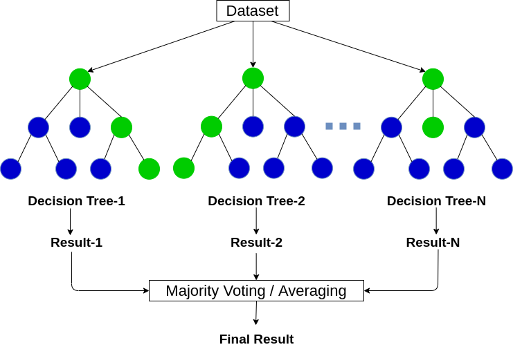

```r
train.rf <- train( Type ~.,data=trainwine, method="rf",
                   trControl  = trainControl("cv",number=5,classProbs=TRUE, summaryFunction=multiClassSummary),
                   preProcess = c("center","scale"),
                   tuneLength = 6,
                   metric= 'logLoss')

print(train.rf)
```

```
## Random Forest
##
## 100 samples
##  13 predictor
##   3 classes: 'Tipo1', 'Tipo2', 'Tipo3'
##
## Pre-processing: centered (13), scaled (13)
## Resampling: Cross-Validated (5 fold)
## Summary of sample sizes: 80, 80, 80, 81, 79
## Resampling results across tuning parameters:
##
##   mtry  logLoss    AUC        prAUC      Accuracy   Kappa      Mean_F1
##    2    0.1877750  0.9988360  0.8181425  0.9894737  0.9830357  0.9916340
##    4    0.1537430  0.9984656  0.8251384  0.9794737  0.9675917  0.9803050
##    6    0.1472960  0.9984656  0.8251384  0.9794737  0.9675917  0.9803050
##    8    0.1515306  0.9969986  0.8154751  0.9489474  0.9195125  0.9485917
##   10    0.1532946  0.9941192  0.7709321  0.9394236  0.9041279  0.9346234
##   13    0.1591355  0.9937366  0.7855966  0.9298997  0.8884014  0.9180361
##   Mean_Sensitivity  Mean_Specificity  Mean_Pos_Pred_Value  Mean_Neg_Pred_Value
##   0.9925926         0.9944444         0.9916667            0.9939394
##   0.9851852         0.9902778         0.9783333            0.9883838
##   0.9851852         0.9902778         0.9783333            0.9883838
##   0.9587302         0.9739899         0.9495455            0.9744444
##   0.9420635         0.9692280         0.9412121            0.9707407
##   0.9253968         0.9644661         0.9347306            0.9674269
##   Mean_Precision  Mean_Recall  Mean_Detection_Rate  Mean_Balanced_Accuracy
##   0.9916667       0.9925926    0.3298246            0.9935185
##   0.9783333       0.9851852    0.3264912            0.9877315
##   0.9783333       0.9851852    0.3264912            0.9877315
##   0.9495455       0.9587302    0.3163158            0.9663600
##   0.9412121       0.9420635    0.3131412            0.9556457
##   0.9347306       0.9253968    0.3099666            0.9449315
##
## logLoss was used to select the optimal model using the smallest value.
## The final value used for the model was mtry = 6.
```

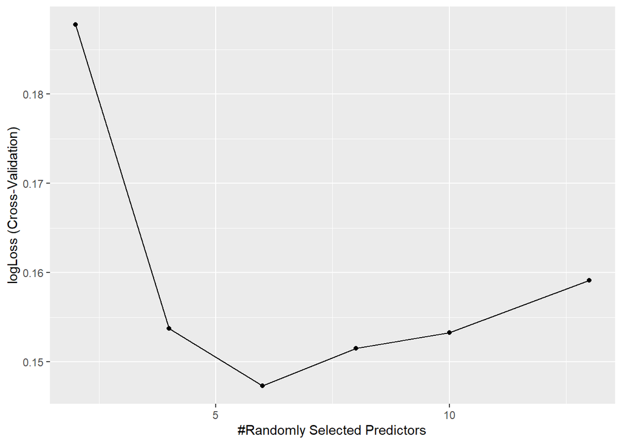

```r
ggplot(train.rf)
```

```r
train.rf$results
```

|  | mtry | logLoss | AUC | prAUC | Accuracy | Kappa | Mean_F1 | Mean_Sensitivity | Mean_Specificity | Mean_Pos_Pred_Value | Mean_Neg_Pred_Value | Mean_Precision | Mean_Recall | Mean_Detection_Rate | Mean_Balanced_Accuracy | logLossSD | AUCSD | prAUCSD | AccuracySD | KappaSD | Mean_F1SD | Mean_SensitivitySD | Mean_SpecificitySD | Mean_Pos_Pred_ValueSD | Mean_Neg_Pred_ValueSD | Mean_PrecisionSD | Mean_RecallSD | Mean_Detection_RateSD | Mean_Balanced_AccuracySD |
| --- | --- | --- | --- | --- | --- | --- | --- | --- | --- | --- | --- | --- | --- | --- | --- | --- | --- | --- | --- | --- | --- | --- | --- | --- | --- | --- | --- | --- | --- |
| 1 | 2 | 0.1877750 | 0.9988360 | 0.8181425 | 0.9894737 | 0.9830357 | 0.9916340 | 0.9925926 | 0.9944444 | 0.9916667 | 0.9939394 | 0.9916667 | 0.9925926 | 0.3298246 | 0.9935185 | 0.03083896 | 0.002602830 | 0.02073858 | 0.02353756 | 0.03793330 | 0.01870697 | 0.01656347 | 0.01242260 | 0.01863390 | 0.01355193 | 0.01863390 | 0.01656347 | 0.007845853 | 0.01449303 |
| 2 | 4 | 0.1537430 | 0.9984656 | 0.8251384 | 0.9794737 | 0.9675917 | 0.9803050 | 0.9851852 | 0.9902778 | 0.9783333 | 0.9883838 | 0.9783333 | 0.9851852 | 0.3264912 | 0.9877315 | 0.03560990 | 0.003431004 | 0.01751078 | 0.02812221 | 0.04445820 | 0.02747241 | 0.02028602 | 0.01353721 | 0.03095696 | 0.01593112 | 0.03095696 | 0.02028602 | 0.009374070 | 0.01684416 |
| 3 | 6 | 0.1472960 | 0.9984656 | 0.8251384 | 0.9794737 | 0.9675917 | 0.9803050 | 0.9851852 | 0.9902778 | 0.9783333 | 0.9883838 | 0.9783333 | 0.9851852 | 0.3264912 | 0.9877315 | 0.04401988 | 0.003431004 | 0.01751078 | 0.02812221 | 0.04445820 | 0.02747241 | 0.02028602 | 0.01353721 | 0.03095696 | 0.01593112 | 0.03095696 | 0.02028602 | 0.009374070 | 0.01684416 |
| 4 | 8 | 0.1515306 | 0.9969986 | 0.8154751 | 0.9489474 | 0.9195125 | 0.9485917 | 0.9587302 | 0.9739899 | 0.9495455 | 0.9744444 | 0.9495455 | 0.9587302 | 0.3163158 | 0.9663600 | 0.04977253 | 0.005044500 | 0.03695753 | 0.05135289 | 0.08134578 | 0.05081783 | 0.04304941 | 0.02778280 | 0.05247436 | 0.02533723 | 0.05247436 | 0.04304941 | 0.017117629 | 0.03540399 |
| 5 | 10 | 0.1532946 | 0.9941192 | 0.7709321 | 0.9394236 | 0.9041279 | 0.9346234 | 0.9420635 | 0.9692280 | 0.9412121 | 0.9707407 | 0.9412121 | 0.9420635 | 0.3131412 | 0.9556457 | 0.05131300 | 0.008065382 | 0.04741028 | 0.04330237 | 0.06859224 | 0.04198572 | 0.03902004 | 0.02399205 | 0.04527300 | 0.02177009 | 0.04527300 | 0.03902004 | 0.014434122 | 0.03043602 |
| 6 | 13 | 0.1591355 | 0.9937366 | 0.7855966 | 0.9298997 | 0.8884014 | 0.9180361 | 0.9253968 | 0.9644661 | 0.9347306 | 0.9674269 | 0.9347306 | 0.9253968 | 0.3099666 | 0.9449315 | 0.05872756 | 0.009935314 | 0.04614815 | 0.04494553 | 0.07208678 | 0.05765099 | 0.06300519 | 0.02461931 | 0.04452264 | 0.02097288 | 0.04452264 | 0.06300519 | 0.014981842 | 0.04179976 |

```r
test.rf<-predict(train.rf,newdata=testwine)
confusionMatrix(as.factor(test.rf),as.factor(testwine$Type))
```

```
## Confusion Matrix and Statistics
##
##           Reference
## Prediction Tipo1 Tipo2 Tipo3
##      Tipo1    23     0     0
##      Tipo2     1    25     1
##      Tipo3     0     0    28
##
## Overall Statistics
##
##                Accuracy : 0.9744
##                  95% CI : (0.9104, 0.9969)
##     No Information Rate : 0.3718
##     P-Value [Acc > NIR] : < 2.2e-16
##
##                   Kappa : 0.9614
##
##  Mcnemar's Test P-Value : NA
##
## Statistics by Class:
##
##                      Class: Tipo1 Class: Tipo2 Class: Tipo3
## Sensitivity                0.9583       1.0000       0.9655
## Specificity                1.0000       0.9623       1.0000
## Pos Pred Value             1.0000       0.9259       1.0000
## Neg Pred Value             0.9818       1.0000       0.9800
## Prevalence                 0.3077       0.3205       0.3718
## Detection Rate             0.2949       0.3205       0.3590
## Detection Prevalence       0.2949       0.3462       0.3590
## Balanced Accuracy          0.9792       0.9811       0.9828
```

```r
Metrica=c('Precision','Recall','F1_Score', 'Accuracy')
Valores=c(Precision(testwine$Type,test.rf),Recall(testwine$Type,test.rf),F1_Score(testwine$Type,test.rf),Accuracy(testwine$Type,test.rf))
rf=data.frame(Metrica,Valores)
#print(rf)
head(rf)
```

|  | Metrica | Valores |
| --- | --- | --- |
| 1 | Precision | 1.0000000 |
| 2 | Recall | 0.9583333 |
| 3 | F1_Score | 0.9787234 |
| 4 | Accuracy | 0.9743590 |

## SVM

### Suppot Vector Machines

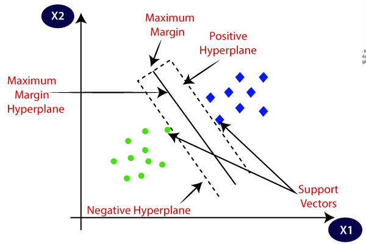

```r
train.svm <- train( Type ~.,data=trainwine, method="svmLinear2",
                   trControl  = trainControl("cv",number=5,classProbs=TRUE, summaryFunction=multiClassSummary),
                   preProcess = c("center","scale"),
                   tuneLength = 6,
                   metric= 'logLoss')

print(train.svm)
```

```
## Support Vector Machines with Linear Kernel
##
## 100 samples
##  13 predictor
##   3 classes: 'Tipo1', 'Tipo2', 'Tipo3'
##
## Pre-processing: centered (13), scaled (13)
## Resampling: Cross-Validated (5 fold)
## Summary of sample sizes: 79, 81, 80, 80, 80
## Resampling results across tuning parameters:
##
##   cost  logLoss    AUC  prAUC      Accuracy   Kappa      Mean_F1
##   0.25  0.1224478  1    0.8271958  0.9794737  0.9674107  0.983268
##   0.50  0.1099649  1    0.8271958  0.9794737  0.9674107  0.983268
##   1.00  0.1140621  1    0.8271958  0.9794737  0.9674107  0.983268
##   2.00  0.1094522  1    0.8271958  0.9794737  0.9674107  0.983268
##   4.00  0.1125691  1    0.8271958  0.9794737  0.9674107  0.983268
##   8.00  0.1106208  1    0.8271958  0.9794737  0.9674107  0.983268
##   Mean_Sensitivity  Mean_Specificity  Mean_Pos_Pred_Value  Mean_Neg_Pred_Value
##   0.9851852         0.9893162         0.9833333            0.9883838
##   0.9851852         0.9893162         0.9833333            0.9883838
##   0.9851852         0.9893162         0.9833333            0.9883838
##   0.9851852         0.9893162         0.9833333            0.9883838
##   0.9851852         0.9893162         0.9833333            0.9883838
##   0.9851852         0.9893162         0.9833333            0.9883838
##   Mean_Precision  Mean_Recall  Mean_Detection_Rate  Mean_Balanced_Accuracy
##   0.9833333       0.9851852    0.3264912            0.9872507
##   0.9833333       0.9851852    0.3264912            0.9872507
##   0.9833333       0.9851852    0.3264912            0.9872507
##   0.9833333       0.9851852    0.3264912            0.9872507
##   0.9833333       0.9851852    0.3264912            0.9872507
##   0.9833333       0.9851852    0.3264912            0.9872507
##
## logLoss was used to select the optimal model using the smallest value.
## The final value used for the model was cost = 2.
```

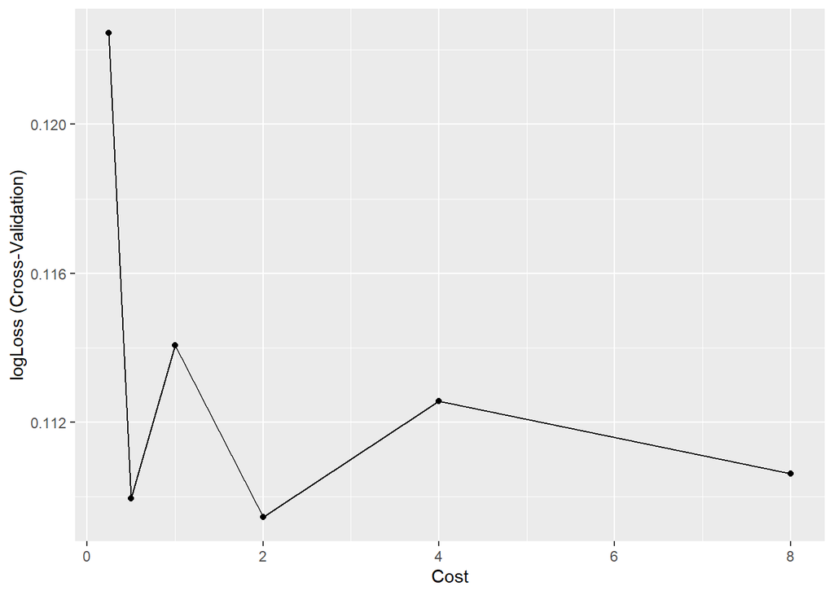

```r
ggplot(train.svm)
```

```r
train.svm$results
```

|  | cost | logLoss | AUC | prAUC | Accuracy | Kappa | Mean_F1 | Mean_Sensitivity | Mean_Specificity | Mean_Pos_Pred_Value | Mean_Neg_Pred_Value | Mean_Precision | Mean_Recall | Mean_Detection_Rate | Mean_Balanced_Accuracy | logLossSD | AUCSD | prAUCSD | AccuracySD | KappaSD | Mean_F1SD | Mean_SensitivitySD | Mean_SpecificitySD | Mean_Pos_Pred_ValueSD | Mean_Neg_Pred_ValueSD | Mean_PrecisionSD | Mean_RecallSD | Mean_Detection_RateSD | Mean_Balanced_AccuracySD |
| --- | --- | --- | --- | --- | --- | --- | --- | --- | --- | --- | --- | --- | --- | --- | --- | --- | --- | --- | --- | --- | --- | --- | --- | --- | --- | --- | --- | --- | --- |
| 1 | 0.25 | 0.1224478 | 1 | 0.8271958 | 0.9794737 | 0.9674107 | 0.983268 | 0.9851852 | 0.9893162 | 0.9833333 | 0.9883838 | 0.9833333 | 0.9851852 | 0.3264912 | 0.9872507 | 0.02899405 | 0 | 0.01293648 | 0.02812221 | 0.04468748 | 0.02291127 | 0.02028602 | 0.01464883 | 0.02282177 | 0.01593112 | 0.02282177 | 0.02028602 | 0.00937407 | 0.01746177 |
| 2 | 0.50 | 0.1099649 | 1 | 0.8271958 | 0.9794737 | 0.9674107 | 0.983268 | 0.9851852 | 0.9893162 | 0.9833333 | 0.9883838 | 0.9833333 | 0.9851852 | 0.3264912 | 0.9872507 | 0.03083388 | 0 | 0.01293648 | 0.02812221 | 0.04468748 | 0.02291127 | 0.02028602 | 0.01464883 | 0.02282177 | 0.01593112 | 0.02282177 | 0.02028602 | 0.00937407 | 0.01746177 |
| 3 | 1.00 | 0.1140621 | 1 | 0.8271958 | 0.9794737 | 0.9674107 | 0.983268 | 0.9851852 | 0.9893162 | 0.9833333 | 0.9883838 | 0.9833333 | 0.9851852 | 0.3264912 | 0.9872507 | 0.02807228 | 0 | 0.01293648 | 0.02812221 | 0.04468748 | 0.02291127 | 0.02028602 | 0.01464883 | 0.02282177 | 0.01593112 | 0.02282177 | 0.02028602 | 0.00937407 | 0.01746177 |
| 4 | 2.00 | 0.1094522 | 1 | 0.8271958 | 0.9794737 | 0.9674107 | 0.983268 | 0.9851852 | 0.9893162 | 0.9833333 | 0.9883838 | 0.9833333 | 0.9851852 | 0.3264912 | 0.9872507 | 0.03380658 | 0 | 0.01293648 | 0.02812221 | 0.04468748 | 0.02291127 | 0.02028602 | 0.01464883 | 0.02282177 | 0.01593112 | 0.02282177 | 0.02028602 | 0.00937407 | 0.01746177 |
| 5 | 4.00 | 0.1125691 | 1 | 0.8271958 | 0.9794737 | 0.9674107 | 0.983268 | 0.9851852 | 0.9893162 | 0.9833333 | 0.9883838 | 0.9833333 | 0.9851852 | 0.3264912 | 0.9872507 | 0.03224201 | 0 | 0.01293648 | 0.02812221 | 0.04468748 | 0.02291127 | 0.02028602 | 0.01464883 | 0.02282177 | 0.01593112 | 0.02282177 | 0.02028602 | 0.00937407 | 0.01746177 |
| 6 | 8.00 | 0.1106208 | 1 | 0.8271958 | 0.9794737 | 0.9674107 | 0.983268 | 0.9851852 | 0.9893162 | 0.9833333 | 0.9883838 | 0.9833333 | 0.9851852 | 0.3264912 | 0.9872507 | 0.03265725 | 0 | 0.01293648 | 0.02812221 | 0.04468748 | 0.02291127 | 0.02028602 | 0.01464883 | 0.02282177 | 0.01593112 | 0.02282177 | 0.02028602 | 0.00937407 | 0.01746177 |

```r
test.svm<-predict(train.svm,newdata=testwine)
confusionMatrix(as.factor(test.svm),as.factor(testwine$Type))
```

```
## Confusion Matrix and Statistics
##
##           Reference
## Prediction Tipo1 Tipo2 Tipo3
##      Tipo1    23     1     0
##      Tipo2     1    23     1
##      Tipo3     0     1    28
##
## Overall Statistics
##
##                Accuracy : 0.9487
##                  95% CI : (0.8739, 0.9859)
##     No Information Rate : 0.3718
##     P-Value [Acc > NIR] : < 2.2e-16
##
##                   Kappa : 0.9228
##
##  Mcnemar's Test P-Value : NA
##
## Statistics by Class:
##
##                      Class: Tipo1 Class: Tipo2 Class: Tipo3
## Sensitivity                0.9583       0.9200       0.9655
## Specificity                0.9815       0.9623       0.9796
## Pos Pred Value             0.9583       0.9200       0.9655
## Neg Pred Value             0.9815       0.9623       0.9796
## Prevalence                 0.3077       0.3205       0.3718
## Detection Rate             0.2949       0.2949       0.3590
## Detection Prevalence       0.3077       0.3205       0.3718
## Balanced Accuracy          0.9699       0.9411       0.9726
```

```r
Metrica=c('Precision','Recall','F1_Score', 'Accuracy')
Valores=c(Precision(testwine$Type,test.svm),Recall(testwine$Type,test.svm),F1_Score(testwine$Type,test.svm),Accuracy(testwine$Type,test.svm))
svm=data.frame(Metrica,Valores)
#print(svm)
head(svm)
```

|  | Metrica | Valores |
| --- | --- | --- |
| 1 | Precision | 0.9583333 |
| 2 | Recall | 0.9583333 |
| 3 | F1_Score | 0.9583333 |
| 4 | Accuracy | 0.9487179 |

## Métricas

### Métricas en modelos de clasificación

- *Accuracy* Indica sobre el total de elementos cuantos son predichos correctamente

$$Accuracy=\frac{TruePositives+TrueNegatives}{TruePositives+FalsePositives+TrueNegatives+FalseNegatives}$$

- *Precision* Indica respecto a los elementos predichos como positivos cuantos lo son efectivamente.

$$Precision=\frac{TruePositives}{TruePositives+FalsePositives}$$

- *Recall - Sensibility* Mide respecto a todos los elementos que efectivamente son positivos cuantos fueron predichos correctamente. (Exhaustividad )

$$Recall=\frac{TruePositives}{TruePositives+FalseNegatives}$$

- *F1-Score* Entrega un promedio ponderado entre precision y recall.

$$F1_{score}=\frac{2⋅Recall⋅Precision}{Recall+Presicion}$$

## Preguntas

##### Pregunta 1

```r
# Seleccione 3 variables del dataset para generar las predicciones y argumente por qué serían buenas variables para predecir el tipo de vino. Puede realizar un EDA o basarse en los gráficos ya incluidos.
# Determine 2 métricas para comparar los modelos, justifique su elección.
# Si se viera en la obligación de NO agregar ciertas variables del dataset, comente sobre cuál o cuáles serían apoyándose en un EDA o los gráficos ya incluídos (Mínimo una variable)
```

Observando el EDA, seleccionamos las siguientes variables:

- Dilución: mide cuán diluido está un tipo de vino, y si observamos el EDA, podemos notar que hay alta variabilidad entre los tipos de vinos, por lo que nos podría ayudar a identificar mejor qué tipo de vino es al momento de correr un modelo.
- Grado alcoholico: mide cuánto alcohol hay en una cierta medida del vino, y la seleccionamos por un argumento similar al anterior, pues hay variabilidad entre los tipos de vino (dan números diferentes entre ellos), lo que ayudaría a identificarlos mejor.
- Intensidad de color: mide el grado en que la luz puede atravesar el vino (ve la opacidad), y tal como en las variables anteriores, esta métrica cambia bastante entre los tipos de vinos.

Las métricas que utilizaremos para comparar modelos son:

- Accuracy: pues queremos ver qué tan bien funcionan nuestros modelos, y si son capaces de identificar bien el tipo de vino.
- F1: Pues considera las métricas de Recall y Precision, lo que nos entrega una información más completa y comparable al pesar de igual manera la cantidad de falsos positivos y falsos negativos (a través de los ratios entregados por Recall y Precision), lo que nos entrega una métrica mucho más acorde a la clasificación cuando tenemos clases desbalanceadas.

Algunas variables que no incorporaremos, son “Hue” o el “Malic”, pues observando el EDA, notamos que para el tipo de vino 1 y 2 son bastantes similares, por lo que no aportan demasiada infromación con respecto a la diferencia ente todas las clases, y, dado que tenemos otras variables que sí varian bastante entre clases, es mejor mantener estas y no agregar posible información que cause confusiones.

##### Pregunta 2

```r
# Corra 2 modelos de clasificación con las variables seleccionadas anteriormente para predecir el tipo de vino.
# Cálcule para cada modelo las metricas seleccionadas para el set de testeo, además muestre la matriz de confusión.
# Comente sobre los resultados, ¿Los modelos poseen capacidad de generalización? ¿se observa overfitting o underfitting?
```

```r
#Primero creamos un dataset con las variables escogidas
df <- wine[,c(1,2,11,13)]
head(df)
```

|  | Type | Alcohol | Color | Dilution |
| --- | --- | --- | --- | --- |
| 1 | Tipo1 | 14.23 | 5.64 | 3.92 |
| 2 | Tipo1 | 13.20 | 4.38 | 3.40 |
| 3 | Tipo1 | 13.16 | 5.68 | 3.17 |
| 4 | Tipo1 | 14.37 | 7.80 | 3.45 |
| 5 | Tipo1 | 13.24 | 4.32 | 2.93 |
| 6 | Tipo1 | 14.20 | 6.75 | 2.85 |

```r
# Creamos los sets de entrenamiento y testeo
train_df=df[sample(nrow(df),100 ), ]
test_df=anti_join(df, train_df)
```

Los modelos a utilizar son KNN y SVM:

KNN

```r
train.knn <- train( Type ~.,
                    data=train_df,
                    method="knn",
                    trControl  = trainControl("cv",
                                              number=5,
                                              classProbs=TRUE,
                                              summaryFunction=multiClassSummary
                                              ),
                   preProcess = c("center","scale"),
                   tuneLength = 6,
                   metric = 'logLoss'
                   )

print(train.knn)
```

```
## k-Nearest Neighbors
##
## 100 samples
##   3 predictor
##   3 classes: 'Tipo1', 'Tipo2', 'Tipo3'
##
## Pre-processing: centered (3), scaled (3)
## Resampling: Cross-Validated (5 fold)
## Summary of sample sizes: 80, 81, 80, 79, 80
## Resampling results across tuning parameters:
##
##   k   logLoss    AUC        prAUC      Accuracy   Kappa      Mean_F1
##    5  1.1512897  0.9749771  0.2377060  0.8803759  0.8195209  0.8793236
##    7  0.8384391  0.9777991  0.3463464  0.9109023  0.8653380  0.9097021
##    9  0.5231815  0.9853434  0.3628822  0.9209023  0.8804903  0.9204076
##   11  0.5527878  0.9811966  0.4262804  0.9203759  0.8800698  0.9198304
##   13  0.2607000  0.9845849  0.5009336  0.9103759  0.8648044  0.9072296
##   15  0.2839454  0.9836691  0.5556853  0.8703759  0.8033900  0.8609840
##   Mean_Sensitivity  Mean_Specificity  Mean_Pos_Pred_Value  Mean_Neg_Pred_Value
##   0.8845238         0.9401557         0.8969841            0.9441972
##   0.9146825         0.9551740         0.9227778            0.9589591
##   0.9242063         0.9603022         0.9317725            0.9635928
##   0.9257937         0.9606685         0.9333598            0.9640079
##   0.9130952         0.9555403         0.9238360            0.9600702
##   0.8702381         0.9350275         0.8983598            0.9426058
##   Mean_Precision  Mean_Recall  Mean_Detection_Rate  Mean_Balanced_Accuracy
##   0.8969841       0.8845238    0.2934586            0.9123397
##   0.9227778       0.9146825    0.3036341            0.9349283
##   0.9317725       0.9242063    0.3069674            0.9422543
##   0.9333598       0.9257937    0.3067920            0.9432311
##   0.9238360       0.9130952    0.3034586            0.9343178
##   0.8983598       0.8702381    0.2901253            0.9026328
##
## logLoss was used to select the optimal model using the smallest value.
## The final value used for the model was k = 13.
```

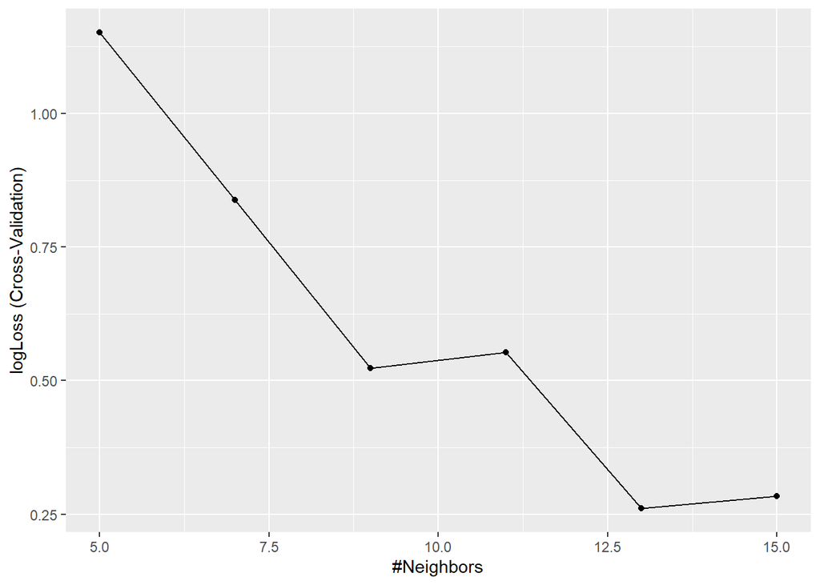

```r
ggplot(train.knn)
```

```r
train.knn$results
```

|  | k | logLoss | AUC | prAUC | Accuracy | Kappa | Mean_F1 | Mean_Sensitivity | Mean_Specificity | Mean_Pos_Pred_Value | Mean_Neg_Pred_Value | Mean_Precision | Mean_Recall | Mean_Detection_Rate | Mean_Balanced_Accuracy | logLossSD | AUCSD | prAUCSD | AccuracySD | KappaSD | Mean_F1SD | Mean_SensitivitySD | Mean_SpecificitySD | Mean_Pos_Pred_ValueSD | Mean_Neg_Pred_ValueSD | Mean_PrecisionSD | Mean_RecallSD | Mean_Detection_RateSD | Mean_Balanced_AccuracySD |
| --- | --- | --- | --- | --- | --- | --- | --- | --- | --- | --- | --- | --- | --- | --- | --- | --- | --- | --- | --- | --- | --- | --- | --- | --- | --- | --- | --- | --- | --- |
| 1 | 5 | 1.1512897 | 0.9749771 | 0.2377060 | 0.8803759 | 0.8195209 | 0.8793236 | 0.8845238 | 0.9401557 | 0.8969841 | 0.9441972 | 0.8969841 | 0.8845238 | 0.2934586 | 0.9123397 | 2.12890674 | 0.03477318 | 0.10330536 | 0.04312458 | 0.06563768 | 0.04398278 | 0.04534067 | 0.02265651 | 0.03693526 | 0.02070655 | 0.03693526 | 0.04534067 | 0.01437486 | 0.03384766 |
| 2 | 7 | 0.8384391 | 0.9777991 | 0.3463464 | 0.9109023 | 0.8653380 | 0.9097021 | 0.9146825 | 0.9551740 | 0.9227778 | 0.9589591 | 0.9227778 | 0.9146825 | 0.3036341 | 0.9349283 | 1.44904212 | 0.03219324 | 0.09071299 | 0.05240755 | 0.07972988 | 0.05466351 | 0.05298028 | 0.02716961 | 0.04273627 | 0.02290334 | 0.04273627 | 0.05298028 | 0.01746918 | 0.03995030 |
| 3 | 9 | 0.5231815 | 0.9853434 | 0.3628822 | 0.9209023 | 0.8804903 | 0.9204076 | 0.9242063 | 0.9603022 | 0.9317725 | 0.9635928 | 0.9317725 | 0.9242063 | 0.3069674 | 0.9422543 | 0.75496695 | 0.02314061 | 0.07627016 | 0.05453435 | 0.08260206 | 0.05436805 | 0.05113508 | 0.02805193 | 0.04530075 | 0.02421829 | 0.04530075 | 0.05113508 | 0.01817812 | 0.03951175 |
| 4 | 11 | 0.5527878 | 0.9811966 | 0.4262804 | 0.9203759 | 0.8800698 | 0.9198304 | 0.9257937 | 0.9606685 | 0.9333598 | 0.9640079 | 0.9333598 | 0.9257937 | 0.3067920 | 0.9432311 | 0.75617002 | 0.02486980 | 0.09424670 | 0.05542685 | 0.08373720 | 0.05665778 | 0.05018704 | 0.02748035 | 0.04750541 | 0.02440541 | 0.04750541 | 0.05018704 | 0.01847562 | 0.03875590 |
| 5 | 13 | 0.2607000 | 0.9845849 | 0.5009336 | 0.9103759 | 0.8648044 | 0.9072296 | 0.9130952 | 0.9555403 | 0.9238360 | 0.9600702 | 0.9238360 | 0.9130952 | 0.3034586 | 0.9343178 | 0.08823517 | 0.01524495 | 0.08058160 | 0.05321216 | 0.08043359 | 0.05452250 | 0.04980910 | 0.02666727 | 0.04599642 | 0.02360553 | 0.04599642 | 0.04980910 | 0.01773739 | 0.03808536 |
| 6 | 15 | 0.2839454 | 0.9836691 | 0.5556853 | 0.8703759 | 0.8033900 | 0.8609840 | 0.8702381 | 0.9350275 | 0.8983598 | 0.9426058 | 0.8983598 | 0.8702381 | 0.2901253 | 0.9026328 | 0.09029580 | 0.01742068 | 0.11657552 | 0.10894553 | 0.16657142 | 0.12049287 | 0.11579213 | 0.05625732 | 0.07871835 | 0.04928111 | 0.07871835 | 0.11579213 | 0.03631518 | 0.08593474 |

```r
#Testeamos
test.knn<-predict(train.knn,newdata=test_df)
confusionMatrix(as.factor(test.knn),as.factor(test_df$Type))
```

```
## Confusion Matrix and Statistics
##
##           Reference
## Prediction Tipo1 Tipo2 Tipo3
##      Tipo1    23     2     0
##      Tipo2     0    31     0
##      Tipo3     0     2    20
##
## Overall Statistics
##
##                Accuracy : 0.9487
##                  95% CI : (0.8739, 0.9859)
##     No Information Rate : 0.4487
##     P-Value [Acc > NIR] : < 2.2e-16
##
##                   Kappa : 0.9217
##
##  Mcnemar's Test P-Value : NA
##
## Statistics by Class:
##
##                      Class: Tipo1 Class: Tipo2 Class: Tipo3
## Sensitivity                1.0000       0.8857       1.0000
## Specificity                0.9636       1.0000       0.9655
## Pos Pred Value             0.9200       1.0000       0.9091
## Neg Pred Value             1.0000       0.9149       1.0000
## Prevalence                 0.2949       0.4487       0.2564
## Detection Rate             0.2949       0.3974       0.2564
## Detection Prevalence       0.3205       0.3974       0.2821
## Balanced Accuracy          0.9818       0.9429       0.9828
```

```r
# Obtenemos las métricas
Metrica=c('F1_Score', 'Accuracy')
Valores=c(F1_Score(test_df$Type,test.knn),Accuracy(test_df$Type,test.knn))
KNN=data.frame(Metrica,Valores)
head(KNN)
```

|  | Metrica | Valores |
| --- | --- | --- |
| 1 | F1_Score | 0.9583333 |
| 2 | Accuracy | 0.9487179 |

SVM

```r
#Usamos los mismos sets de train y test

train.svm <- train( Type ~.,data=train_df, method="svmLinear2",
                   trControl  = trainControl("cv",number=5,classProbs=TRUE, summaryFunction=multiClassSummary),
                   preProcess = c("center","scale"),
                   tuneLength = 6,
                   metric= 'logLoss')

print(train.svm)
```

```
## Support Vector Machines with Linear Kernel
##
## 100 samples
##   3 predictor
##   3 classes: 'Tipo1', 'Tipo2', 'Tipo3'
##
## Pre-processing: centered (3), scaled (3)
## Resampling: Cross-Validated (5 fold)
## Summary of sample sizes: 80, 80, 78, 81, 81
## Resampling results across tuning parameters:
##
##   cost  logLoss    AUC        prAUC      Accuracy   Kappa      Mean_F1
##   0.25  0.2770191  0.9878434  0.8278591  0.8991866  0.8478410  0.9013687
##   0.50  0.2754711  0.9880418  0.8280568  0.8886603  0.8322737  0.8889833
##   1.00  0.2764651  0.9852640  0.8243956  0.8881340  0.8317157  0.8898025
##   2.00  0.2836341  0.9859585  0.8253170  0.8991866  0.8477079  0.9014908
##   4.00  0.2852658  0.9866911  0.8259375  0.8991866  0.8481071  0.8992397
##   8.00  0.3027790  0.9857982  0.8249984  0.8988038  0.8477712  0.8984882
##   Mean_Sensitivity  Mean_Specificity  Mean_Pos_Pred_Value  Mean_Neg_Pred_Value
##   0.9027778         0.9487027         0.9084656            0.9503588
##   0.8932540         0.9439408         0.8917989            0.9454304
##   0.8948413         0.9435134         0.8951323            0.9457068
##   0.9027778         0.9487027         0.9068783            0.9500536
##   0.9027778         0.9494963         0.9029101            0.9505586
##   0.9043651         0.9494963         0.9079365            0.9516880
##   Mean_Precision  Mean_Recall  Mean_Detection_Rate  Mean_Balanced_Accuracy
##   0.9084656       0.9027778    0.2997289            0.9257402
##   0.8917989       0.8932540    0.2962201            0.9185974
##   0.8951323       0.8948413    0.2960447            0.9191774
##   0.9068783       0.9027778    0.2997289            0.9257402
##   0.9029101       0.9027778    0.2997289            0.9261371
##   0.9079365       0.9043651    0.2996013            0.9269307
##
## logLoss was used to select the optimal model using the smallest value.
## The final value used for the model was cost = 0.5.
```

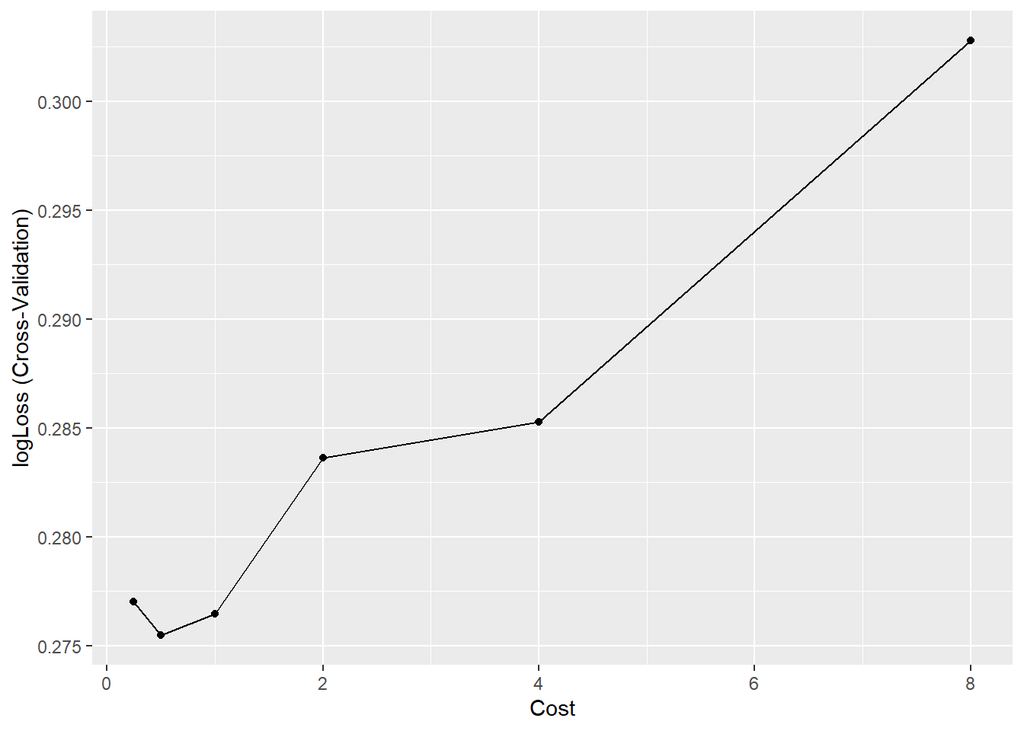

```r
ggplot(train.svm)
```